# Exam_One_A

# Terminology

1. What is the difference between a *population* and a *sample*?

Answer: A population is the entire group. A sample is a portion of the group or population

good

2. What is the difference between a *statistic* and a *parameter*. Give an example of a *statistic*.

Answer: A statistic an observation from the data of a sample of the population. A parameter is a observation from the data of the entire population. An example of a statistic is the polling predictions for an election. The results from a sample from the population of who people voted for gives the prediction or statistic of how the whole population might vote.

good

3. In a data set, what is the difference between an *observation* and a *variable*?

Answer: A observation is the results true of false question such as if they are going to vote for a certain candidates. A veriable is a number that comes from a question such as a persons height. Its more of a measurement.

An observation is one element of a data set: a person, a tree etc. (7.5/9)

# Exploratory Data Analysis

Use one of the following two chunks to load the data set `Alelager`.

If you have the `resampledata` package installed use:

```r
library(resampledata)
BeerData<-Alelager
head(BeerData)
```

```
##   ID Type Alcohol Calories
## 1  1  Ale    5.50      160
## 2  2  Ale    5.40      156
## 3  3  Ale    4.85      146
## 4  4  Ale    4.50      150
## 5  5  Ale    5.20      160
## 6  6  Ale    5.30      174
```

**or**, you can use:

```r
#BeerData<-read.csv("https://sites.google.com/site/chiharahesterberg/data2/Alelager.csv")
#head(BeerData)
```

1. Create side-by-side box plots of the alcohol content, grouped by beer type. Comment on the information the box plots convey.

```r
Aledata <- subset(BeerData, select=Alcohol, subset=Type=="Ale", drop=T)
Lagerdata <- subset(BeerData, select=Alcohol, subset=Type=="Lager", drop=T)
Lagerdata
```

```
##  [1] 5.00 5.00 5.00 4.90 4.94 4.90 4.70 4.75 4.55 4.81 4.40 5.00 5.00 4.60 4.79
## [16] 5.00 5.80 4.90
```

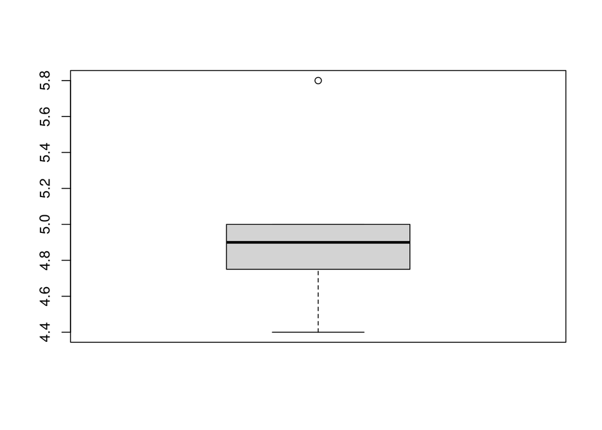

```r
#boxplot(Lagerdata ~ Aledata) side by side isint working
boxplot(Lagerdata)
```

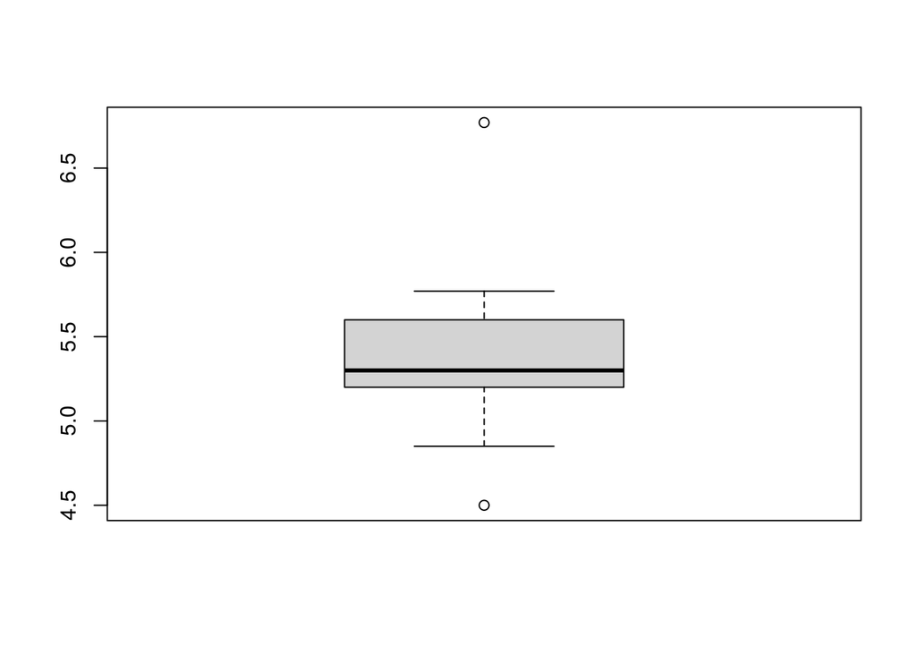

```r
boxplot(Aledata)
```

2. Create a histogram of the calorie content of all beers in the data set. Describe the distribution.

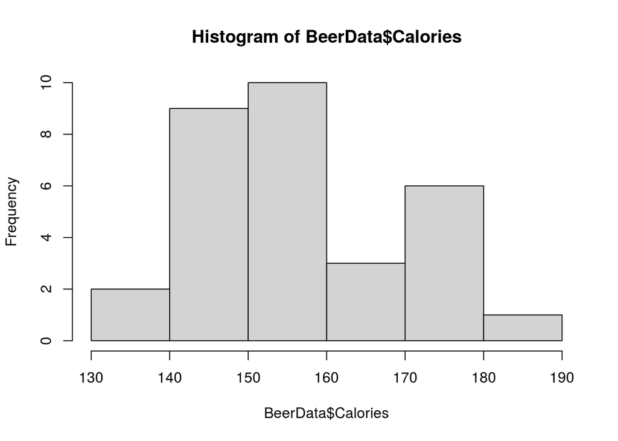

```r
hist(BeerData$Calories)
```

Description of distribution: The distribution is fairly centered but is not normal because there is a large drop in beers that have 160 to 170 calories. The most amount of beers have around 150 to 160 calories with a frequency of about 10.

good (4/6) (11.5/15)

3. Sampling Distribution
- Simulate the sampling distribution of the mean of the number of calories, for samples of size 3.

```r
cal=BeerData$Calories
sim=10000
Xbar=NULL
for (i in 1:sim)
  {mysample <- sample(cal, size=3,replace=TRUE)
  Xbar[i] <- mean(mysample)}
```

- Create a histogram and describe the simulated sampling distribution.

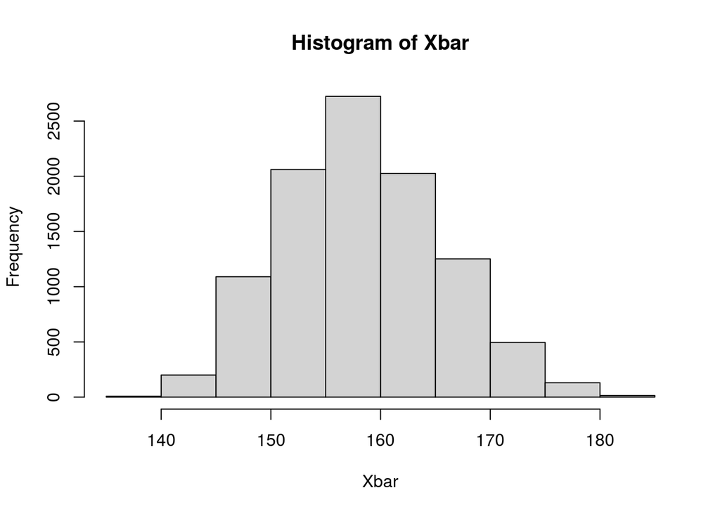

```r
hist(Xbar)
```

Description of sampling distribution: The distribution is normal. The range is about 140 to 180 excluding outliers. the beers most commonly where between 155 and 160 calories with a frequency of just over 2500.

- Use the simulation to find the probability that the average calorie content of 3 beers is less than 150 calories.

```r
mean(Xbar<150)
```

```
## [1] 0.1217
```

- Use the simulation to find the probability that the average calorie content of 3 beers is more than 160 calories.

```r
mean(Xbar>160)
```

```
## [1] 0.3917
```

good (7/7) (18.5/22)

4. The following code generates two ecdfs, one for calories of ales, one for calories of lagers.

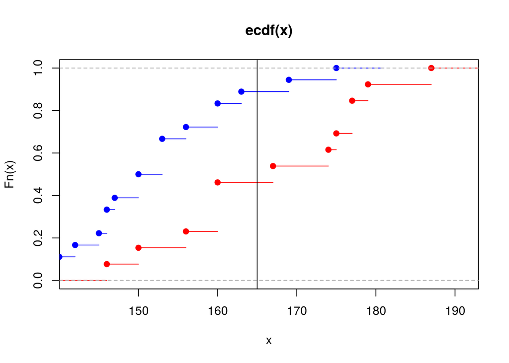

```r
Ales <- subset(BeerData, select=Calories, subset=Type=="Ale", drop=T)
Lagers <- subset(BeerData, select=Calories, subset=Type=="Lager", drop=T)
#plot.new()
plot.ecdf(Ales, col="red")
plot.ecdf(Lagers, col="blue", add=TRUE)
abline(v=165)
```

What percentage of ales in the data set have less than 165 calories? Ans= about 50%

good (3/3) (21.5/25)

# Permutation test

Conduct a permutation test to determine whether there is a difference in the mean calorie content between ales and lagers. Your test should start with a statement of the formal hypotheses and finish with a conclusion.

Put each step in its own chunk and **clearly explain what each chunk is doing and what information the output provides.**

Can’t get it to run so I commented out to knit

```r
#doesnt run
#DiffInPairs<-BeerData$Ale-BeerData$Lager
#observed <- mean(DiffInPairs)
#observed
```

It doesn’t run because there aren’t any pairs. When you try BeerData$Ale-BeerData$Lager, you are trying to subtract two vectors that don’t have the same length. The thing to computer is the mean of the calories in the Ales and the mean of the calories in the Lagers, and then take the difference of those means. (3/3)

```r
#poolsize <- length(BeerData$Calories)
#poolsize
```

Resampleing the data from 10000 possibilities to see if the hypothesis is common or rare

```r
#sample(c(-1,1), poolsize, replace=T)
#N <- 10^4-1 #sampling from 10000 options
#result <- numeric(N)
#for (i in 1:N)
#{Sign <- sample(c(-1,1), poolsize, replace=T) #random swapping assignment
#  Diff <- Sign*DiffInPairs #compute differences within matched pairs
#result[i] <- mean(Diff) #assign the mean of the differences to the result vector
#}
```

This is also trying to set up a matched pairs test. An example of a matched pairs might be if we had beers grouped by producer: one an ale, the other a lager.

Finds a tale by looking for the smallest and then multiplying it by 2 to get both tales of the distribution.

```r
#2*min((sum(result >= observed)+1)/(N+1),
#(sum(result <= observed)+1)/(N+1))
```

```r
#hist(DiffInPairs)
#hist(results)
```

My data isnt working I think it is in issue when I’m calling it for the DiffInPairs, because it is giving me no values.

(2/13) (23.5/38)

(I put in several r-chunks. You might use more, you might use fewer.)

# Critical reading

Below, I conduct a permutation test to test whether there was, on average, a difference in the annual snow fall in Colorado in the years 2019 and 2020. Identify the mistake and fix it.

First, we load and briefly inspect the data:

```r
SnowData <- read.csv("https://www.dropbox.com/s/h8lkjdqoqui3bzw/TestDownload2.csv?dl=1")
head(SnowData)
```

```
##                           StationName Snow2020 Snow2019
## 1               BAYFIELD 6.2 N, CO US     55.3    182.1
## 2 BLACK CANYON OF THE GUNNISON, CO US    103.9    165.0
## 3           BLACK FOREST 3.8 W, CO US    110.4    184.6
## 4           BLACK FOREST 6 WNW, CO US     73.9    125.3
## 5                BOULDER 1.6 S, CO US    124.4    124.8
## 6                BOULDER 2.9 S, CO US    113.9    116.0
```

The data shows annual snow fall recorded at 51 NOAA weather station in Colorado in 2019, and 2020.

The formal statements of the hypotheses are:

$$H_0: \mu_{d_{2020}-d_{2019}}=0$$

$$H_A: \mu_{d_{2020}-d_{2019}}\neq 0$$

where $d_{2020}-d_{2019}$ represents the difference in snow fall by station.

We’ll compute the difference in snowfall at each station and compute the observed mean of differences:

```r
DiffAtStations<-SnowData$Snow2020-SnowData$Snow2019
Observed<-mean(DiffAtStations)
Observed
```

```
## [1] -25.45098
```

Next, we’ll pool the data in order to find a permutation distribution:

```r
#The poolsize is wrong. it should be used as how many element are in the pool not a vector of each element but Im getting na for some reason.
PooledData<- c(SnowData$Snow2020, SnowData$Snow2019)
#PooledData=length(SnowData$Snow2020)
```

Here is the loop that generates a permutation distribution:

```r
N=10^4
SampleDist<-numeric(N)
for (i in 1:N)
{index<-sample(102,51, replace=F)
SampleDist[i]<- mean(PooledData[index]-PooledData[-index])}
```

Finally, we compute the $p$-value for our observed statistic:

```r
2*min((sum(SampleDist >= Observed)+1)/(N+1),
(sum(SampleDist <= Observed)+1)/(N+1))
```

```
## [1] 0.00459954
```

Since the $p$-value is small we reject the null hypothesis and conclude that the mean difference in snow depth between 2019 and 2020 was different.

The poolsize is wrong. it should be used as how many element are in the pool not a vector of each element

The idea here is that the data is matched and so this should be run as a matched pairs test. (0/5) (23.5/43)